# Question 1: Which clinical features and which blood biomarkers are associated with incident diabetes? These clinical features and biomarkers can potentially be risk or protective factors for diabetes development

## 1.1 Clinical features

A cox regression is done for clinical features. Based on the HR value and p value for each clinical features, we conclude that

2.Intense exercise, being ex-smoker, high LDL, long hours fasting glucose and high BMI alse increased the risk of diabetes. (NOTE: A further investigation of exercise found that although intense exercise for competitive sports increase the risk of diabete, exercise at least 3 hours a week gives the lowest development of diabetes.)

3.DBP, total fiber, fasting, junk food, and hbA1C are protective factors that reduced the risk of diabetes.

5.Based on HR (hazard ratio), these factors of following factors: age, SBP, and fasting_insulin, have relatively small effect (<10%) on delevepment of diabetes.

Table1. Cox regression table for clinical features. HR(hazard ratio) is the exp(coef). HR =1: no effect. HR <1: reduction in the hazard HR>1: Increase in hazard #

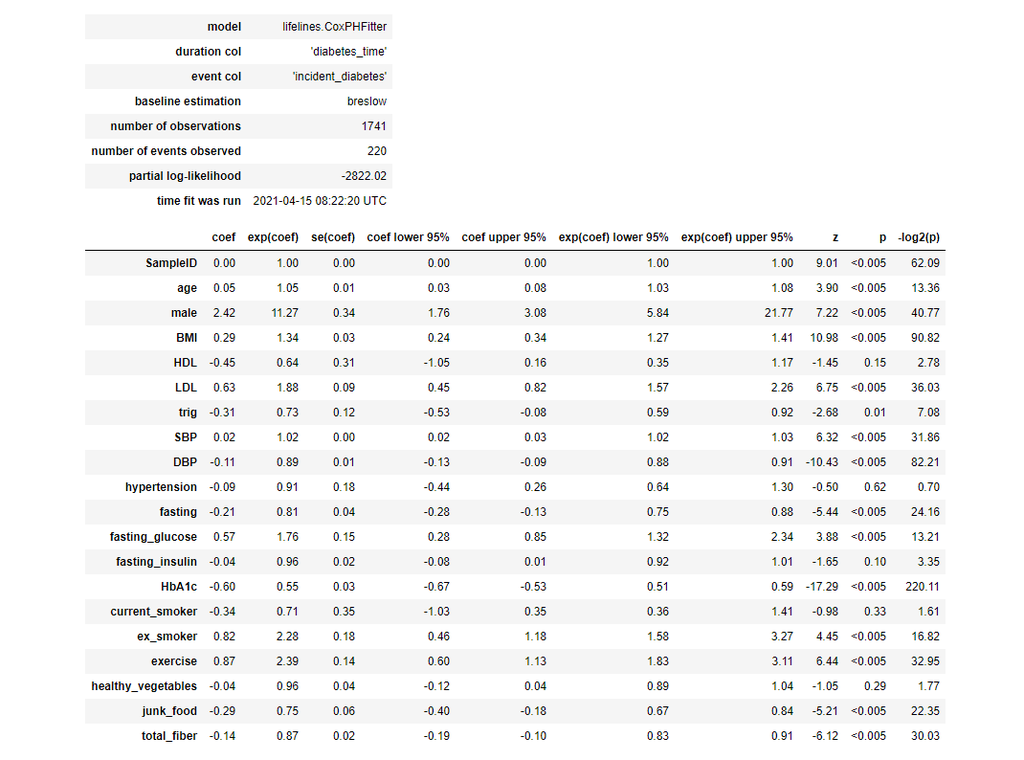

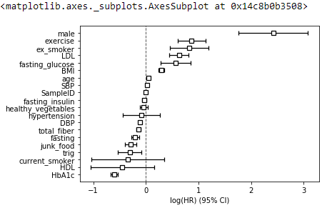

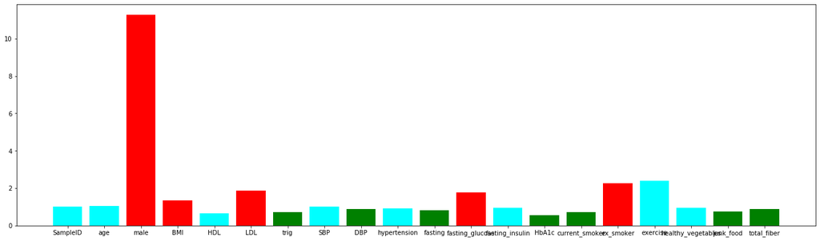

Figure 2. A closer look at one clinical feature, exercise time. Analysis shows that although intense exercise increase the risk of diabetes, 3 hr exercise per week has the lowest risk of diabetes. This is not a linear trend.

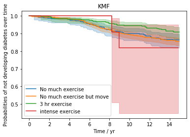

## 1.2 Blood biomarkers

Figure 3 show the importance of all biomarkers calculated in logistic regression. The positive ones increase the risk and the negatives biomarker reduce the risk. The top 5 risky blood biomarkers are 'mtb_501727', 'mtb_1849581', 'mtb_76692', 'mtb_1620434', 'mtb_1295574' and the top safe markers are 'mtb_296151', 'mtb_908115', 'mtb_1213920', 'mtb_1881432', and 'mtb_1677449'. Although the marker 'mtb_1677449' has high importance, it was not included in the later calculation due to its low statistical significance.

The numbers in the dataset were changed from float64 to int32 after multiply by 100. This is reduced memory used by half.

Figure 3. Importance of biomakers calculated by logistic regression

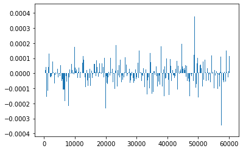

Figure 4a. Importance of top 5 risky blood biomarkers and top 5 safe biomakers calculated by logistic regression. Red are risky biomarkers and green are safe biomarkers.

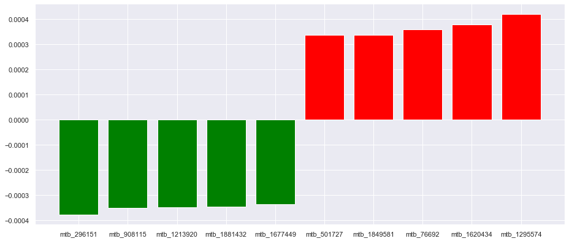

Figure 4b. barplot of p values of top 5 risky blood biomarkers and top 5 safe biomakers. Red are risky biomarkers and green are safe biomarkers.

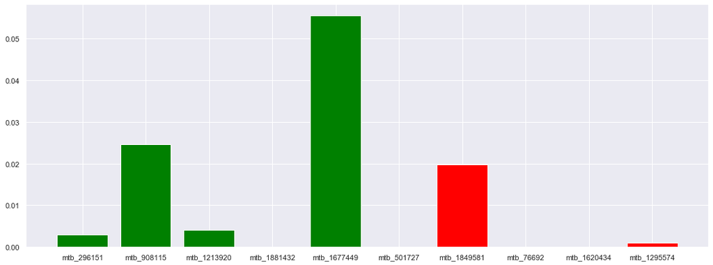

Figure 5. Histogram of p-values for top 200 important facotors. 117 features have p-value < 0.05

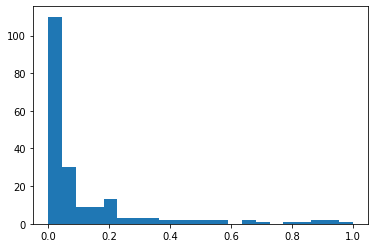

# Question 2. How can we use blood biomarkers alone to predict the risk of developing diabetes?

## 2.1 Predict incident diabetes using four ML models.

A subset of the data containing 7697 patients and 117 blood biomakers was selected. We can easily include more features, but results show that this data size is enough to generate a good prediction of diabetes development.

To reduce the effect of outliers, log transformation on the dataset is performed.

A list of ML model is performed prediction, including SVM, random forrest, logistic regression and XGboost. After some tuning of parameters, logistic regression and XGboost achived a ROC auc score of 0.95, which indicates a good prediction accuracy.

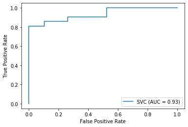

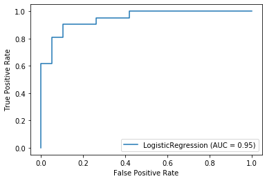

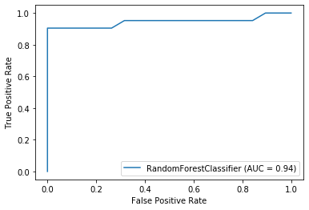

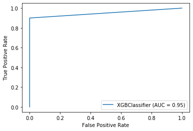

## 2.2 Predict diabetes time using two ML models.

Linear regression and XGboost regression model were used and trained to predict the diabetes time. MSE is used to evaluate the models. The MSE for linear regression and trained XGBOOST is 7.203 and 7.096 respectively.

# Question 3. : Are there any clusters based on blood biomarkers among the participants who developed incident diabetes? Can you identify which blood biomarkers defined these clusters?

### 3.1 Determine the optimum number of clusters

Based on hierachial dendograph and the elbow plot of k-means clustering, the optimum number of cluster is 3.

Figure 7. Hierachial dendograph show 3 well seperated clusters of patients

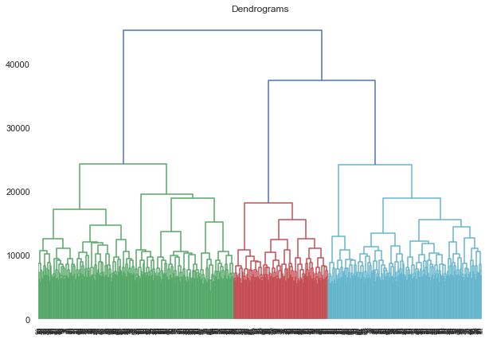

.

Figure 8. Elbow plot

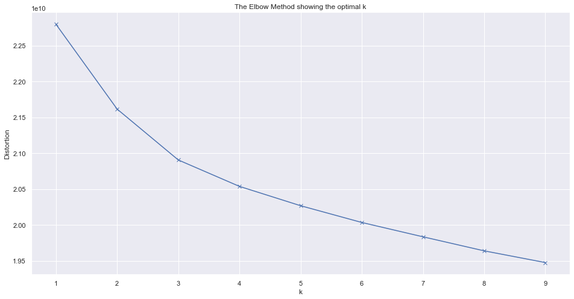

## 3.2 Clustering of patient.

The clustering result from k-means (Figure 9) and hierarchial shown (Figure 10) in figure 9 and 10 are very similar and reasonable seperated in space.

Figure 9. The k-means clustering of patients. Visualisation by PCA(left) and tSNE (right)

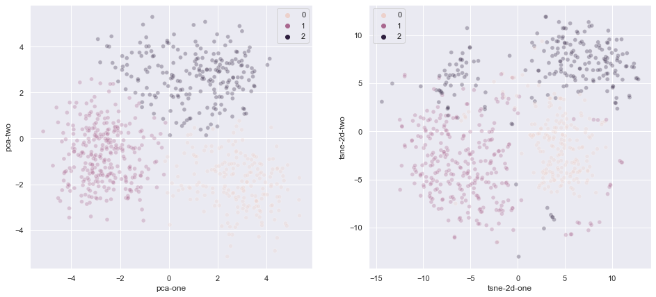

Figure 10. The hierarchial clustering of patients. Visualisation by PCA(left) and tSNE (right)

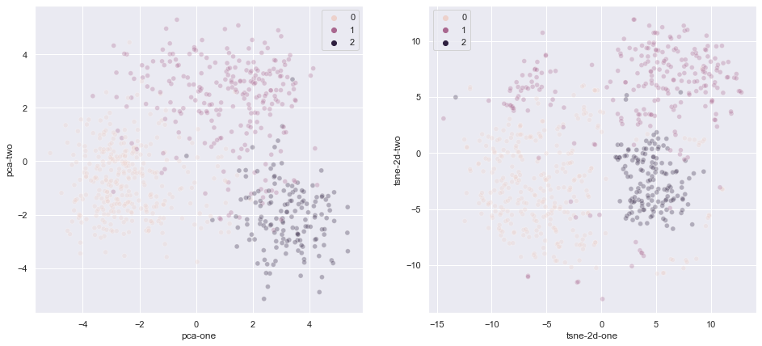

## 3.3 Markers of each cluster.

Table 3 showed the top 5 biomarkers for each cluster and figure 11 showed the contribution of the top 25 biomarkers for each clusters. Figure 12 shows the expression level of top 3 biomarkers from each group.

Table 3. Each column represent a cluster and the rows are the top biomarkers specific for the cluster.

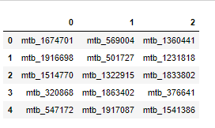

Figure 11. Top 25 markers contributing to each cluster

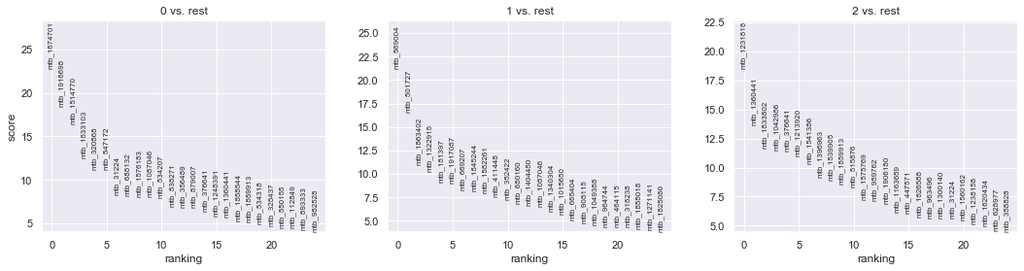

Figure 12. Expression of 9 biomarkers in cluster 0, cluster 1, cluster 2.

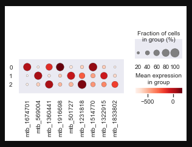